# ps5-gapminderData

Lydia Sorbo

2023-02-17

## 1. **Load and Check Data**

**Question 1.2**

```r
library(tidyverse)
```

```r
gapminder <- read_delim("gapminder.csv.bz2")
```

The gapminder data has 13055 rows and 25 columns.

**Question 1.3**

```r
gapminder %>%
  sample_n(5)
```

```
## # A tibble: 5 × 25
##   iso3  name  iso2  region sub-r…¹ inter…²  time total…³ ferti…⁴ lifeE…⁵ child…⁶
##   <chr> <chr> <chr> <chr>  <chr>   <chr>   <dbl>   <dbl>   <dbl>   <dbl>   <dbl>
## 1 IND   India IN    Asia   Southe… <NA>     2011  1.25e9    2.51    67.1    55.1
## 2 BRB   Barb… BB    Ameri… Latin … Caribb…  1982  2.54e5    1.92    73.0    24.4
## 3 NER   Niger NE    Africa Sub-Sa… Wester…  1981  6.16e6    7.87    39.4   319.
## 4 KEN   Kenya KE    Africa Sub-Sa… Easter…  2018  5.14e7    3.49    66.3    44.6
## 5 CHAN… <NA>  <NA>  <NA>   <NA>    <NA>     2007  1.55e5    1.55    80.8    NA
## # … with 14 more variables: youthFemaleLiteracy <dbl>, youthMaleLiteracy <dbl>,
## #   adultLiteracy <dbl>, GDP_PC <dbl>, accessElectricity <dbl>,
## #   agriculturalLand <dbl>, agricultureTractors <dbl>, cerealProduction <dbl>,
## #   fertilizerHa <dbl>, co2 <dbl>, greenhouseGases <dbl>, co2_PC <dbl>,
## #   pm2.5_35 <dbl>, battleDeaths <dbl>, and abbreviated variable names
## #   ¹`sub-region`, ²`intermediate-region`, ³totalPopulation, ⁴fertilityRate,
## #   ⁵lifeExpectancy, ⁶childMortality
```

## 2. **Descriptive Statistics**

**Question 2.1**

There are 250 countries in the dataset.

There are 249 iso2 codes in the dataset.

There are 253 iso3 codes in the dataset.

**Question 2.2.a**

```r
gapminder %>%
  group_by(iso2) %>%
  reframe(totalCountries = length(unique(name)), unique(name)) %>%
  tail(5)
```

```
## # A tibble: 5 × 3
##   iso2  totalCountries `unique(name)`
##   <chr>          <int> <chr>
## 1 ZA                 1 South Africa
## 2 ZM                 1 Zambia
## 3 ZW                 1 Zimbabwe
## 4 <NA>               2 <NA>
## 5 <NA>               2 Namibia
```

The iso2 code for Namibia is being recognized as missing since it is “NA”, resulting in 249 iso2 codes for 250 countries.

**Question 2.2.b**

```r
gapminder %>%
  group_by(iso3) %>%
  reframe(totalCountries = length(unique(name)), unique(name))
```

```
## # A tibble: 253 × 3
##    iso3  totalCountries `unique(name)`
##    <chr>          <int> <chr>
##  1 ABW                1 Aruba
##  2 AFG                1 Afghanistan
##  3 AGO                1 Angola
##  4 AIA                1 Anguilla
##  5 ALA                1 Åland Islands
##  6 ALB                1 Albania
##  7 AND                1 Andorra
##  8 ARE                1 United Arab Emirates
##  9 ARG                1 Argentina
## 10 ARM                1 Armenia
## # … with 243 more rows
```

The iso3 codes CHANISL, NLD CURACAO, and GBM have missing country names, resulting in 253 iso3 codes for 250 countries.

**Question 2.3**

```r
gapminder %>%
  filter(!is.na(time)) %>%
  summarize(minYear = min(time), maxYear = max(time))
```

```
## # A tibble: 1 × 2
##   minYear maxYear
##     <dbl>   <dbl>
## 1    1960    2019
```

The minimum year is 1960 and the maximum year is 2019.

## 3. **CO2 Emissions**

**Question 3.1**

```r
gapminder %>%
  group_by(time) %>%
  filter(is.na(co2)) %>%
  filter(is.na(co2_PC)) %>%
  reframe(missingco2 = length(co2), missingco2PC = length(co2_PC)) %>%
  arrange(desc(missingco2)) %>%
  head(5)
```

```
## # A tibble: 5 × 3
##    time missingco2 missingco2PC
##   <dbl>      <int>        <int>
## 1  2017        217          217
## 2  2018        217          217
## 3  2019        217          217
## 4  1960         60           60
## 5  1961         60           60
```

2017-19 have the most missing emissions data at 217.

**Question 3.2**

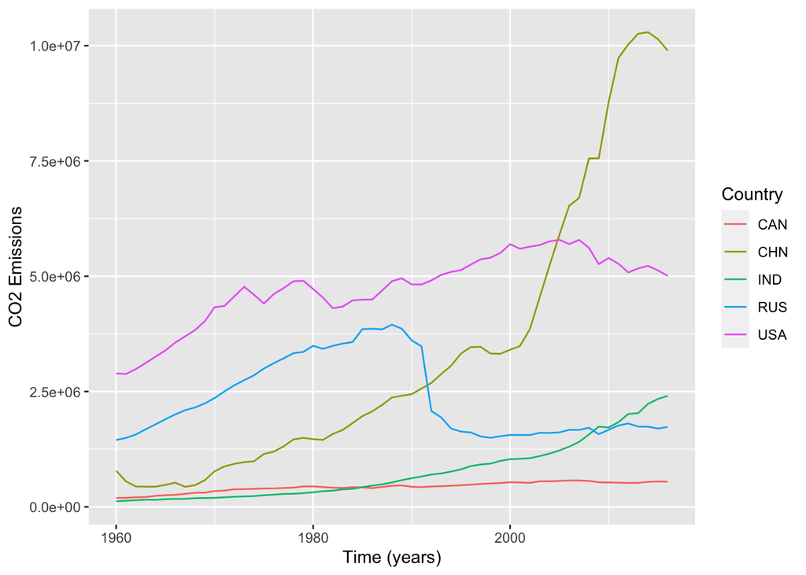

```r
gapminder %>%
  filter(!is.na(co2)) %>%
  filter(iso3 == "CHN" | iso3 == "USA" |
           iso3 == "IND" | iso3 == "CAN" | iso3 == "RUS") %>%
  ggplot(aes(time, co2, col=iso3)) +
  geom_line() +
  labs(x = "Time (years)", y = "CO2 Emissions",
       col = "Country")
```

China has the highest CO2 emissions, followed by the United States. While China and the United States emissions are currently decreasing, India’s emissions are increasing. Russia and Canada’s emissions are staying constant.

**Question 3.3**

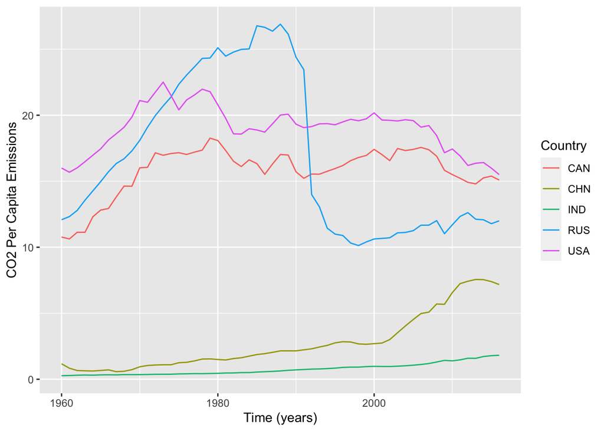

```r
gapminder %>%
  filter(!is.na(co2_PC)) %>%
  filter(iso3 == "USA" | iso3 == "CHN" |
           iso3 == "IND" | iso3 == "CAN" | iso3 == "RUS") %>%
  ggplot(aes(time, co2_PC, col=factor(iso3))) +
  geom_line() +
  labs(x = "Time (years)", y = "CO2 Per Capita Emissions",
       col = "Country")
```

The United States has the highest CO2 emissions per capita, followed by Canada. While China, the United States, and Canada emissions per capita are currently decreasing, India and Russia emissions are beginning to increase.

**Question 3.4**

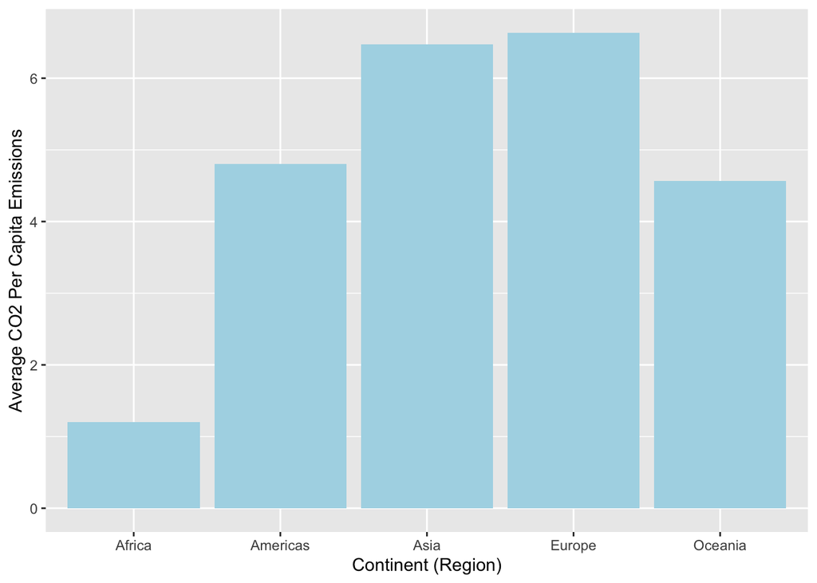

```r
averageEmissions <- gapminder %>%
  filter(time == "2016") %>%
  group_by(region) %>%
  filter(!is.na(region)) %>%
  filter(!is.na(co2_PC)) %>%
  reframe(avgEmissions = mean(co2_PC))

averageEmissions %>%
  ggplot() +
  geom_col(aes(x = region, y = avgEmissions),
               fill="lightblue") +
  labs(x = "Continent (Region)", y = "Average CO2 Per Capita Emissions")
```

Europe has the highest average CO2 per capita emissions, followed by Asia and the Americas. Africa has significantly lower average CO2 per capita emissions than the other regions.

**Question 3.5**

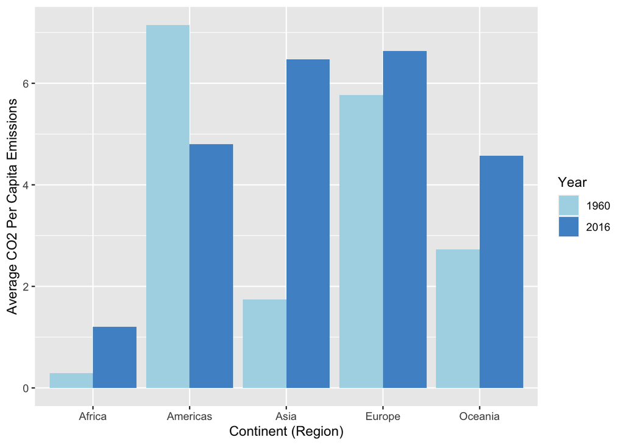

```r
averageEmissionsYear <- gapminder %>%
  filter(time == "1960" | time == "2016") %>%
  group_by(region, time) %>%
  filter(!is.na(region)) %>%
  filter(!is.na(co2_PC)) %>%
  reframe(avgEmissions = mean(co2_PC))

averageEmissionsYear %>%
   ggplot(aes(x = region, y = avgEmissions, fill=factor(time))) +
   geom_col(position = "dodge") +
   scale_fill_manual(
      values = c("1960"="lightblue", "2016" = "steelblue3")
   ) +
    labs(x = "Continent (Region)", y = "Average CO2 Per Capita Emissions", fill = "Year")
```

**Question 3.6** (using 2016 data since many missing values in 2019)

```r
gapminder %>%
  filter(time == "2016") %>%
  group_by(region) %>%
  filter(!is.na(region)) %>%
  filter(!is.na(name)) %>%
  filter(!is.na(co2_PC)) %>%
  filter(rank(co2_PC) <= 3 | rank(desc(co2_PC)) <= 3) %>%
  arrange(co2_PC) %>%
  reframe(region, name, co2_PC)
```

```
## # A tibble: 30 × 3
##    region   name                               co2_PC
##    <chr>    <chr>                               <dbl>
##  1 Africa   Congo, Democratic Republic of the  0.0256
##  2 Africa   Somalia                            0.0455
##  3 Africa   Burundi                            0.0472
##  4 Africa   Seychelles                         6.39
##  5 Africa   Libya                              7.79
##  6 Africa   South Africa                       8.48
##  7 Americas Haiti                              0.275
##  8 Americas Nicaragua                          0.887
##  9 Americas Honduras                           1.06
## 10 Americas Canada                            15.1
## # … with 20 more rows
```

## 4. **GDP Per Capita**

**Question 4.1**

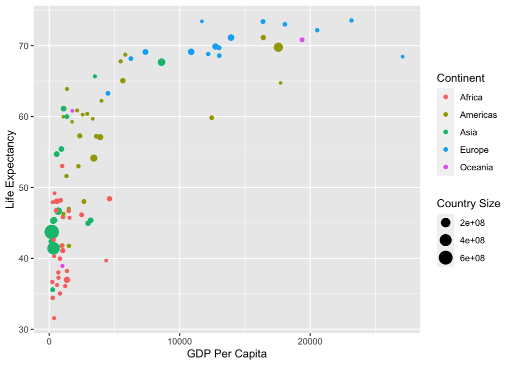

```r
gdp <- gapminder %>%
  filter(time == "1960") %>%
  filter(!is.na(GDP_PC)) %>%
  filter(!is.na(lifeExpectancy)) %>%
  filter(!is.na(name)) %>%
  group_by(name)

ggplot(data = gdp) +
  geom_point(mapping = aes(x = GDP_PC, y = lifeExpectancy,
                           color = region, size = totalPopulation)) +
    labs(x = "GDP Per Capita", y = "Life Expectancy",
         col = "Continent", size = "Country Size")
```

As GDP per capita increases, life expectancy increases. European countries seem to have higher GDP per capita, while African countries have lower GDP per capita.

**Question 4.2**

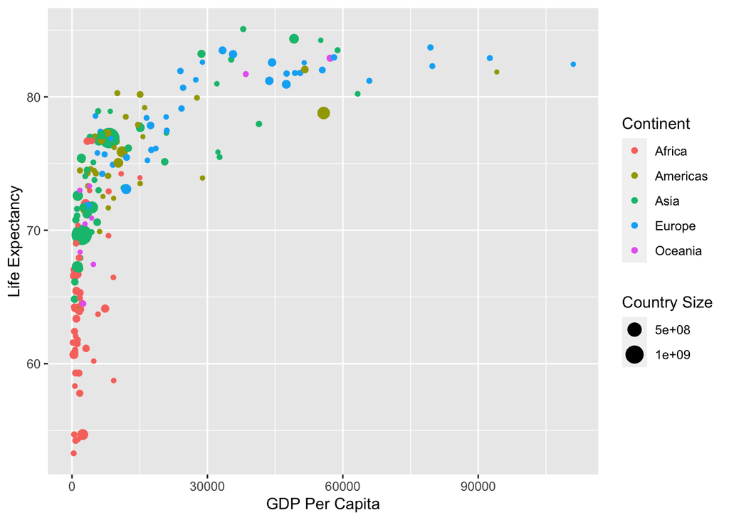

```r
gdp2019 <- gapminder %>%
  filter(time == "2019") %>%
  filter(!is.na(GDP_PC)) %>%
  filter(!is.na(lifeExpectancy)) %>%
  filter(!is.na(name)) %>%
  group_by(name)

ggplot(data = gdp2019) +
  geom_point(mapping = aes(x = GDP_PC, y = lifeExpectancy,
                           color = region, size = totalPopulation)) +
    labs(x = "GDP Per Capita", y = "Life Expectancy",
         col = "Continent", size = "Country Size")
```

**Question 4.3**

Country size and life expectancy has increased significantly overall. However, similarly in both graphs, as GDP per capita increases, life expectancy increases. African countries have the lowest GDP per capita in both graphs while European countries have the highest. The world population and life expectancy has increased significantly over the last 60 years.

**Question 4.4**

```r
gapminder %>%
  group_by(region, time) %>%
  filter(!is.na(time)) %>%
  filter(time %in% c("1960", "2019")) %>%
  filter(!is.na(region)) %>%
  filter(!is.na(lifeExpectancy)) %>%
  reframe("avgLifeExpectancy" = mean(lifeExpectancy)) %>%
  arrange((time))
```

```
## # A tibble: 10 × 3
##    region    time avgLifeExpectancy
##    <chr>    <dbl>             <dbl>
##  1 Africa    1960              41.5
##  2 Americas  1960              58.6
##  3 Asia      1960              51.6
##  4 Europe    1960              68.3
##  5 Oceania   1960              56.4
##  6 Africa    2019              64.1
##  7 Americas  2019              75.8
##  8 Asia      2019              74.6
##  9 Europe    2019              79.4
## 10 Oceania   2019              73.5
```

These results match corresponding figures.

**Question 4.5**

```r
gapminder %>%
  group_by(region, time) %>%
  filter(!is.na(time)) %>%
  filter(time %in% c("1960", "2019")) %>%
  filter(!is.na(region)) %>%
  filter(!is.na(lifeExpectancy)) %>%
  reframe("avgLifeExpectancy" = mean(lifeExpectancy)) %>%
  mutate(prev = lag(avgLifeExpectancy), growth = avgLifeExpectancy - prev) %>%
  filter(time == "2019") %>%
  arrange(desc(time))
```

```
## # A tibble: 5 × 5
##   region    time avgLifeExpectancy  prev growth
##   <chr>    <dbl>             <dbl> <dbl>  <dbl>
## 1 Africa    2019              64.1  41.5   22.6
## 2 Americas  2019              75.8  58.6   17.2
## 3 Asia      2019              74.6  51.6   23.0
## 4 Europe    2019              79.4  68.3   11.1
## 5 Oceania   2019              73.5  56.4   17.1
```

Asia has had the most growth in average life expectancy, followed by Africa. Europe has had the least growth but has the highest average overall.

**Question 6.6**

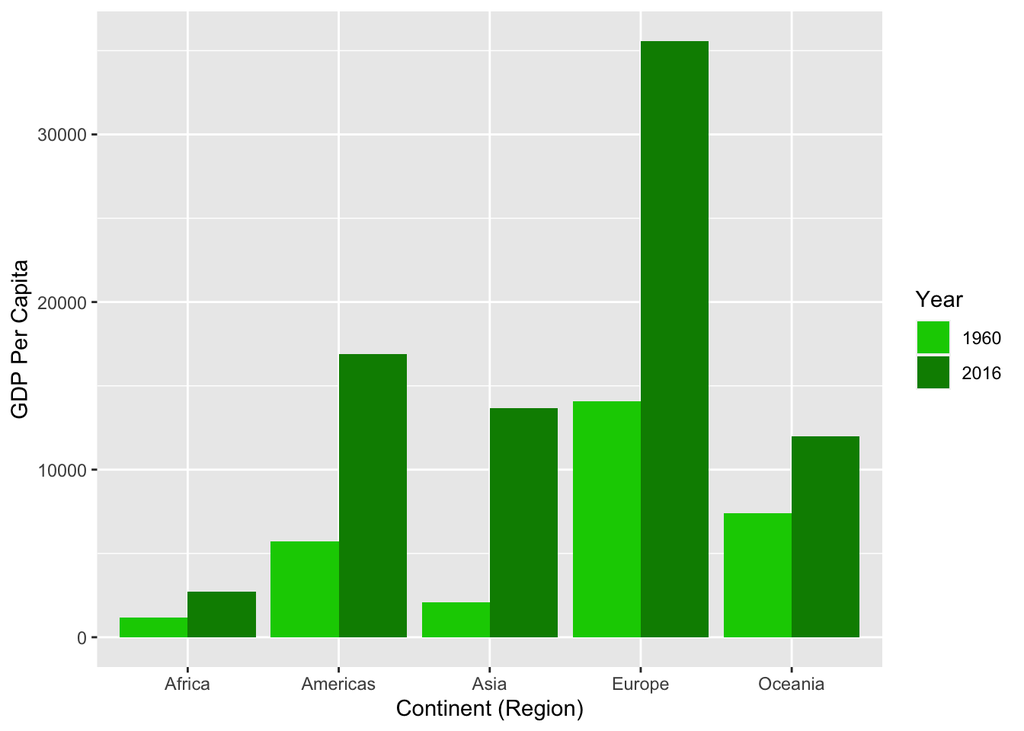

```r
gdpPerCap <- gapminder %>%
  filter(time == "1960" | time == "2016") %>%
  group_by(region, time) %>%
  filter(!is.na(region)) %>%
  filter(!is.na(GDP_PC)) %>%
  reframe(avgGDPperCap = mean(GDP_PC))

gdpPerCap %>%
   ggplot(aes(x = region, y = avgGDPperCap, fill=factor(time))) +
   geom_col(position = "dodge") +
   scale_fill_manual(
      values = c("1960"="green3", "2016" = "green4")
   ) +
    labs(x = "Continent (Region)", y = "GDP Per Capita", fill = "Year")
```

**Question 4.7**

```r
gapminder %>%
  group_by(name, time) %>%
  filter(!is.na(time)) %>%
  filter(time == "2019") %>%
  filter(!is.na(name)) %>%
  filter(!is.na(lifeExpectancy)) %>%
  reframe(lifeExpectancy) %>%
  arrange(desc(lifeExpectancy)) %>%
  mutate(ranking = row_number()) %>%
  filter(rank(desc(lifeExpectancy)) <= length(name)) %>%
  arrange(ranking) %>%
  filter(name == "United States of America")
```

```
## # A tibble: 1 × 4
##   name                      time lifeExpectancy ranking
##   <chr>                    <dbl>          <dbl>   <int>
## 1 United States of America  2019           78.8      46
```

```r
gapminder %>%
  group_by(name, time) %>%
  filter(!is.na(time)) %>%
  filter(time == "1960") %>%
  filter(!is.na(name)) %>%
  filter(!is.na(lifeExpectancy)) %>%
  reframe(lifeExpectancy) %>%
  arrange(desc(lifeExpectancy)) %>%
  mutate(ranking = row_number()) %>%
  filter(rank(desc(lifeExpectancy)) <= length(name)) %>%
  arrange(ranking) %>%
  filter(name == "United States of America")
```

```
## # A tibble: 1 × 4
##   name                      time lifeExpectancy ranking
##   <chr>                    <dbl>          <dbl>   <int>
## 1 United States of America  1960           69.8      17
```

The U.S. ranking in 2019 was 46th and was 17th in 1960.

**Question 4.8**

```r
gapminder %>%
  group_by(name, time) %>%
  filter(!is.na(time)) %>%
  filter(time == "1960") %>%
  filter(!is.na(name)) %>%
  filter(!is.na(lifeExpectancy)) %>%
  reframe(lifeExpectancy) %>%
  arrange(desc(lifeExpectancy)) %>%
  mutate(ranking = row_number()) %>%
  filter(rank(desc(lifeExpectancy)) <= length(name)) %>%
  arrange(ranking) %>%
  mutate(relativeRank = round(ranking/length(name), 4)) %>%
  filter(name == "United States of America")
```

```
## # A tibble: 1 × 5
##   name                      time lifeExpectancy ranking relativeRank
##   <chr>                    <dbl>          <dbl>   <int>        <dbl>
## 1 United States of America  1960           69.8      17       0.0904
```

```r
gapminder %>%
  group_by(name, time) %>%
  filter(!is.na(time)) %>%
  filter(time == "2019") %>%
  filter(!is.na(name)) %>%
  filter(!is.na(lifeExpectancy)) %>%
  reframe(lifeExpectancy) %>%
  arrange(desc(lifeExpectancy)) %>%
  mutate(ranking = row_number()) %>%
  filter(rank(desc(lifeExpectancy)) <= length(name)) %>%
  arrange(ranking) %>%
  mutate(relativeRank = round(ranking/length(name), 4)) %>%
  filter(name == "United States of America")
```

```
## # A tibble: 1 × 5
##   name                      time lifeExpectancy ranking relativeRank
##   <chr>                    <dbl>          <dbl>   <int>        <dbl>
## 1 United States of America  2019           78.8      46        0.235
```

The U.S relative rank was .0904 in 1960 and .2347 in 2019.

**I spent 6-7 hours on this assigment**